# Tutorial 10

Swarag

2023-11-12

# Interpreting Regression Output

- First let’s see how to interpret regression output

```r
x = 1:100
y = 3*x + rnorm(100, sd = 50)
data <- data.frame(x = x, y=y)
model <- lm(y~1+x, data = data)
summary(model)
```

```
##
## Call:
## lm(formula = y ~ 1 + x, data = data)
##
## Residuals:
##      Min       1Q   Median       3Q      Max
## -137.341  -28.082    2.445   30.693   85.350
##
## Coefficients:
##             Estimate Std. Error t value Pr(>|t|)
## (Intercept)   5.2446     9.4699   0.554    0.581
## x             3.0156     0.1628  18.523   <2e-16 ***
## ---
## Signif. codes:  0 '***' 0.001 '**' 0.01 '*' 0.05 '.' 0.1 ' ' 1
##
## Residual standard error: 47 on 98 degrees of freedom
## Multiple R-squared:  0.7778, Adjusted R-squared:  0.7756
## F-statistic: 343.1 on 1 and 98 DF,  p-value: < 2.2e-16
```

```r
anova(model)
```

```
## Analysis of Variance Table
##
## Response: y
##           Df Sum Sq Mean Sq F value    Pr(>F)
## x          1 757740  757740   343.1 < 2.2e-16 ***
## Residuals 98 216436    2209
## ---
## Signif. codes:  0 '***' 0.001 '**' 0.01 '*' 0.05 '.' 0.1 ' ' 1
```

```r
cohens_d(y,x, data = data)
```

```
## Cohen's d |       95% CI
## ------------------------
## 1.46      | [1.15, 1.78]
##
## - Estimated using pooled SD.
```

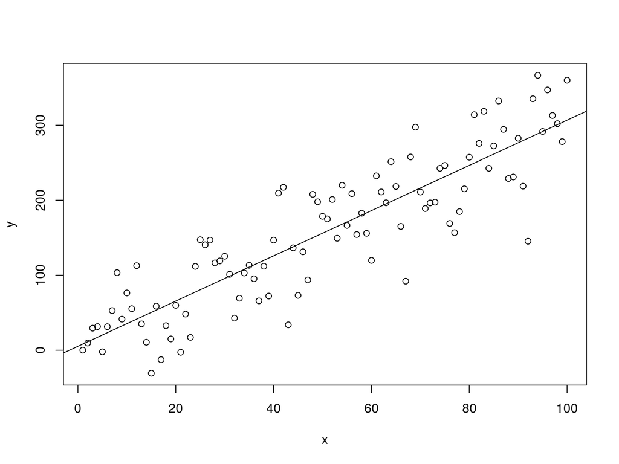

```r
plot(x,y)
abline(lm(y ~ x))
```

```r
# With more noise
x = 1:100
y = 3*x + rnorm(100, sd = 500)
data <- data.frame(x = x, y=y)
model <- lm(y~1+x, data = data)
summary(model)
```

```
##
## Call:
## lm(formula = y ~ 1 + x, data = data)
##
## Residuals:
##      Min       1Q   Median       3Q      Max
## -1246.31  -308.20   -17.74   360.82  1124.19
##
## Coefficients:
##             Estimate Std. Error t value Pr(>|t|)
## (Intercept)   18.750    102.483   0.183    0.855
## x              2.851      1.762   1.618    0.109
##
## Residual standard error: 508.6 on 98 degrees of freedom
## Multiple R-squared:  0.02602,    Adjusted R-squared:  0.01608
## F-statistic: 2.618 on 1 and 98 DF,  p-value: 0.1089
```

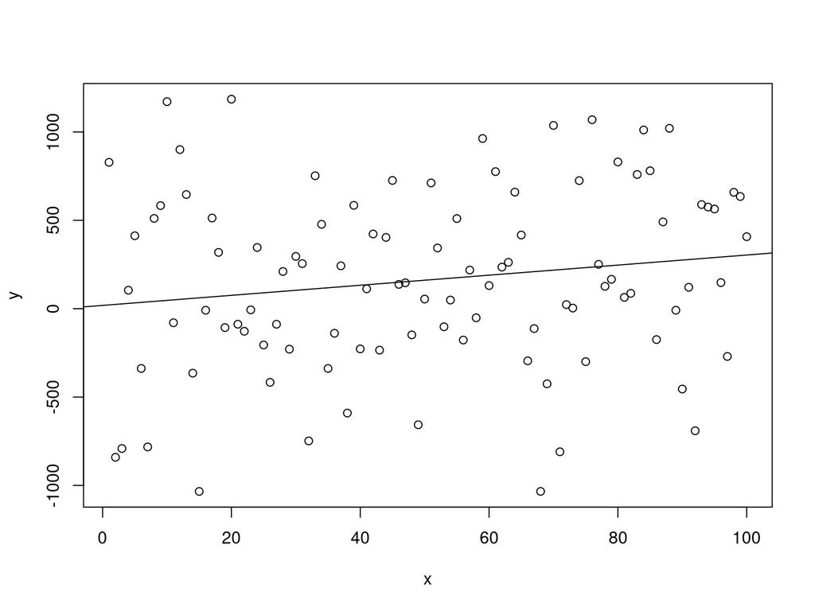

```r
plot(x,y)
abline(lm(y ~ x))
```

```r
anova(model)
```

```
## Analysis of Variance Table
##
## Response: y
##           Df   Sum Sq Mean Sq F value Pr(>F)
## x          1   677089  677089  2.6178 0.1089
## Residuals 98 25347751  258651
```

```r
cohens_d(y,x, data = data)
```

```
## Cohen's d |       95% CI
## ------------------------
## 0.31      | [0.03, 0.59]
##
## - Estimated using pooled SD.
```

```r
# With lower slope
x = 1:100
y = 0.5*x + rnorm(100, sd = 50)
data <- data.frame(x = x, y=y)
model <- lm(y~1+x, data = data)
summary(model)
```

```
##
## Call:
## lm(formula = y ~ 1 + x, data = data)
##
## Residuals:
##      Min       1Q   Median       3Q      Max
## -103.027  -33.807    4.098   28.394  114.606
##
## Coefficients:
##             Estimate Std. Error t value Pr(>|t|)
## (Intercept)  -3.4119     9.0275  -0.378  0.70629
## x             0.4553     0.1552   2.933  0.00417 **
## ---
## Signif. codes:  0 '***' 0.001 '**' 0.01 '*' 0.05 '.' 0.1 ' ' 1
##
## Residual standard error: 44.8 on 98 degrees of freedom
## Multiple R-squared:  0.08072,    Adjusted R-squared:  0.07134
## F-statistic: 8.605 on 1 and 98 DF,  p-value: 0.004175
```

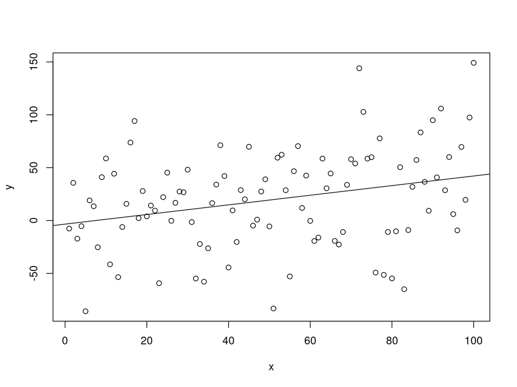

```r
plot(x,y)
abline(lm(y ~ x))
```

```r
anova(model)
```

```
## Analysis of Variance Table
##
## Response: y
##           Df Sum Sq Mean Sq F value   Pr(>F)
## x          1  17270   17270  8.6048 0.004175 **
## Residuals 98 196687    2007
## ---
## Signif. codes:  0 '***' 0.001 '**' 0.01 '*' 0.05 '.' 0.1 ' ' 1
```

```r
cohens_d(y,x, data = data)
```

```
## Cohen's d |         95% CI
## --------------------------
## -0.80     | [-1.09, -0.51]
##
## - Estimated using pooled SD.
```

- discuss

# Intrpreting slopes(interaction effects)

- Let’s try with simulated data

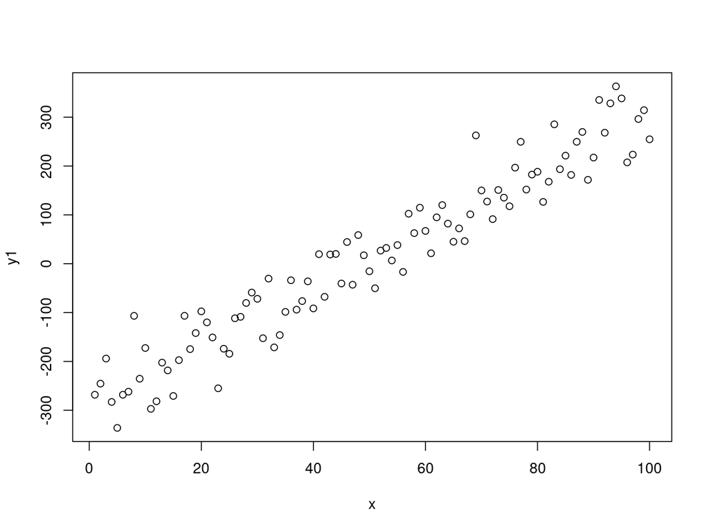

```r
x <- 1:100
y1 <- 6*(x - 50) + rnorm(100, sd = 50)
y2 <- 1*(x - 50) + rnorm(100, sd = 50)

plot(x, y1)
```

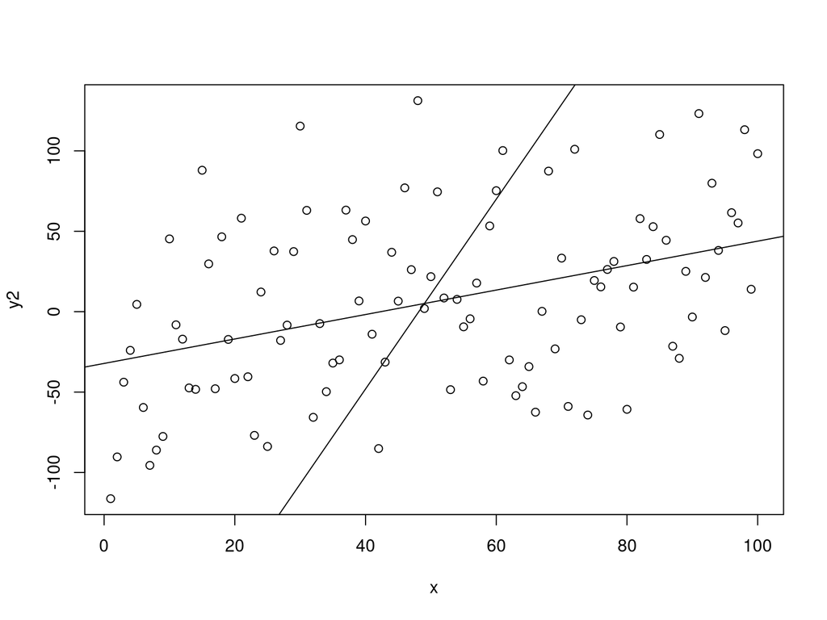

```r
plot(x, y2)
abline(lm(y1 ~ x))
abline(lm(y2 ~ x))
```

```r
dataC0 <- data.frame(x= x, y = y2)
dataC0['condition'] <- 0
dataC1 <- data.frame(x= x, y = y1)
dataC1['condition'] <- 1

data_1 <- rbind(dataC0, dataC1)
data_1$x <- scale(data_1$x)
data_1$y <- scale(data_1$y)

mod <- lm(y~x*condition, data = data_1)
summary(mod)
```

```
##
## Call:
## lm(formula = y ~ x * condition, data = data_1)
##
## Residuals:
##      Min       1Q   Median       3Q      Max
## -0.80962 -0.25717 -0.00586  0.26804  1.05950
##
## Coefficients:
##             Estimate Std. Error t value Pr(>|t|)
## (Intercept) -0.02909    0.03845  -0.757    0.450
## x            0.16700    0.03855   4.333 2.35e-05 ***
## condition    0.05819    0.05437   1.070    0.286
## x:condition  1.12884    0.05451  20.708  < 2e-16 ***
## ---
## Signif. codes:  0 '***' 0.001 '**' 0.01 '*' 0.05 '.' 0.1 ' ' 1
##
## Residual standard error: 0.3845 on 196 degrees of freedom
## Multiple R-squared:  0.8544, Adjusted R-squared:  0.8522
## F-statistic: 383.4 on 3 and 196 DF,  p-value: < 2.2e-16
```

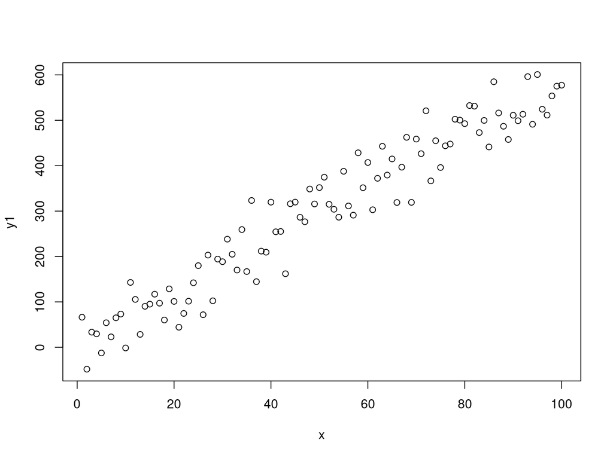

```r
x <- 1:100
y1 <- 6*x + rnorm(100, sd = 50)
y2 <- 1*x + rnorm(100, sd = 50)

plot(x, y1)
```

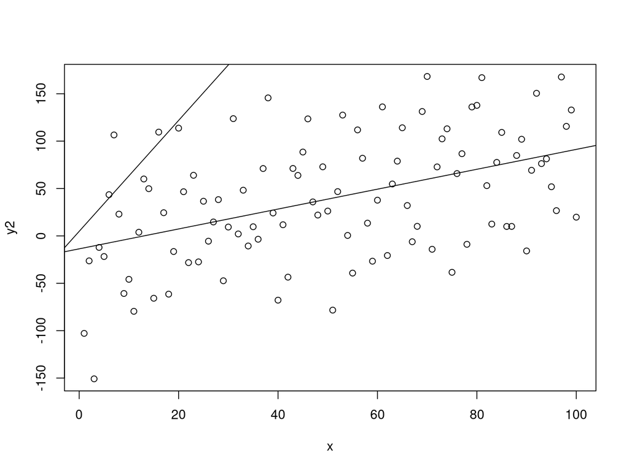

```r
plot(x, y2)
abline(lm(y1 ~ x))
abline(lm(y2 ~ x))
```

```r
dataC0 <- data.frame(x= x, y = y2)
dataC0['condition'] <- 0
dataC1 <- data.frame(x= x, y = y1)
dataC1['condition'] <- 1

data_1 <- rbind(dataC0, dataC1)
data_1$x <- scale(data_1$x)
data_1$y <- scale(data_1$y)

mod <- lm(y~x*condition, data = data_1)
summary(mod)
```

```
##
## Call:
## lm(formula = y ~ x * condition, data = data_1)
##
## Residuals:
##      Min       1Q   Median       3Q      Max
## -0.75301 -0.20669  0.00407  0.21331  0.64071
##
## Coefficients:
##             Estimate Std. Error t value Pr(>|t|)
## (Intercept) -0.70024    0.02869 -24.411  < 2e-16 ***
## x            0.16296    0.02876   5.667 5.14e-08 ***
## condition    1.40048    0.04057  34.523  < 2e-16 ***
## x:condition  0.74576    0.04067  18.337  < 2e-16 ***
## ---
## Signif. codes:  0 '***' 0.001 '**' 0.01 '*' 0.05 '.' 0.1 ' ' 1
##
## Residual standard error: 0.2869 on 196 degrees of freedom
## Multiple R-squared:  0.919,  Adjusted R-squared:  0.9177
## F-statistic: 740.8 on 3 and 196 DF,  p-value: < 2.2e-16
```

- What do you observe?

# Practise Problems

- Salary vs Expertise

```r
data <- data.frame(
  Years_Exp = c(1.1, 1.3, 1.5, 2.0, 2.2, 2.9, 3.0, 3.2, 3.2, 3.7),
  Salary = c(39343.00, 46205.00, 37731.00, 43525.00,
             39891.00, 56642.00, 60150.00, 54445.00, 64445.00, 57189.00)
)
```

-Given this data infer about the dependence of salary on years of experience. Plot the data along with the linear model and explain based on the coefficients.

```r
lm= lm(formula = Salary ~ Years_Exp,
         data = data)
summary(lm)
```

```
##
## Call:
## lm(formula = Salary ~ Years_Exp, data = data)
##
## Residuals:
##     Min      1Q  Median      3Q     Max
## -8171.3 -3695.9  -717.2  4219.7  7362.1
##
## Coefficients:
##             Estimate Std. Error t value Pr(>|t|)
## (Intercept)    28217       5130   5.501 0.000573 ***
## Years_Exp       9021       2003   4.503 0.001995 **
## ---
## Signif. codes:  0 '***' 0.001 '**' 0.01 '*' 0.05 '.' 0.1 ' ' 1
##
## Residual standard error: 5482 on 8 degrees of freedom
## Multiple R-squared:  0.7171, Adjusted R-squared:  0.6817
## F-statistic: 20.28 on 1 and 8 DF,  p-value: 0.001995
```

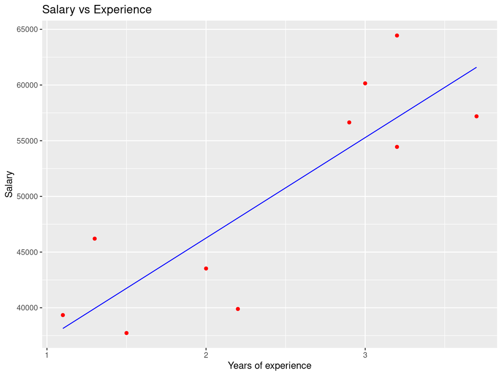

```r
ggplot() + geom_point(aes(x = data$Years_Ex,
                          y = data$Salary), colour = 'red') +
  geom_line(aes(x = data$Years_Ex,
                y = predict(lm, newdata = data)), colour = 'blue') +

  ggtitle('Salary vs Experience') +
  xlab('Years of experience') +
  ylab('Salary')
```

## Example 2 - We’ll use the marketing data set. It contains the impact of three advertising medias (youtube, facebook and newspaper) on sales. Data are the advertising budget in thousands of dollars along with the sales. The advertising experiment has been repeated 200 times with different budgets and the observed sales have been recorded.

```r
load(file='marketing.rda')
head(marketing)
```

```
##   youtube facebook newspaper sales
## 1  276.12    45.36     83.04 26.52
## 2   53.40    47.16     54.12 12.48
## 3   20.64    55.08     83.16 11.16
## 4  181.80    49.56     70.20 22.20
## 5  216.96    12.96     70.08 15.48
## 6   10.44    58.68     90.00  8.64
```

- Infer which media is most effective for marketing?

```r
model <- lm(sales~1+youtube + facebook + newspaper, data = marketing)
summary(model)
```

```
##
## Call:
## lm(formula = sales ~ 1 + youtube + facebook + newspaper, data = marketing)
##
## Residuals:
##      Min       1Q   Median       3Q      Max
## -10.5932  -1.0690   0.2902   1.4272   3.3951
##
## Coefficients:
##              Estimate Std. Error t value Pr(>|t|)
## (Intercept)  3.526667   0.374290   9.422   <2e-16 ***
## youtube      0.045765   0.001395  32.809   <2e-16 ***
## facebook     0.188530   0.008611  21.893   <2e-16 ***
## newspaper   -0.001037   0.005871  -0.177     0.86
## ---
## Signif. codes:  0 '***' 0.001 '**' 0.01 '*' 0.05 '.' 0.1 ' ' 1
##
## Residual standard error: 2.023 on 196 degrees of freedom
## Multiple R-squared:  0.8972, Adjusted R-squared:  0.8956
## F-statistic: 570.3 on 3 and 196 DF,  p-value: < 2.2e-16
```

- News paper advertisement doesn’t seems to have an effect at all.
- Facebook seems like a better advertising platform. ## Practise Problem 3
- These data include measurements of the diameter, height and volume of 31 black cherry trees. Note that the ‘Girth’ is actually the diameter at breast height (DBH) in inches, ‘Height’ is height in feet, and ‘Volume’ is volume in cubic feet.

```r
data(trees)
head(trees)
```

```
##   Girth Height Volume
## 1   8.3     70   10.3
## 2   8.6     65   10.3
## 3   8.8     63   10.2
## 4  10.5     72   16.4
## 5  10.7     81   18.8
## 6  10.8     83   19.7
```

What is the relationship between girth and height?

```r
model<- lm(Girth ~ 1 + Height, data = trees)
summary(model)
```

```
##
## Call:
## lm(formula = Girth ~ 1 + Height, data = trees)
##
## Residuals:
##     Min      1Q  Median      3Q     Max
## -4.2386 -1.9205 -0.0714  2.7450  4.5384
##
## Coefficients:
##             Estimate Std. Error t value Pr(>|t|)
## (Intercept) -6.18839    5.96020  -1.038  0.30772
## Height       0.25575    0.07816   3.272  0.00276 **
## ---
## Signif. codes:  0 '***' 0.001 '**' 0.01 '*' 0.05 '.' 0.1 ' ' 1
##
## Residual standard error: 2.728 on 29 degrees of freedom
## Multiple R-squared:  0.2697, Adjusted R-squared:  0.2445
## F-statistic: 10.71 on 1 and 29 DF,  p-value: 0.002758
```

- discuss ## Practise problem 4
- Consider the Weather data

```r
data <- read.csv("kanpur-weather.csv")
head(data)
```

```
##     name   datetime tempmax tempmin temp feelslikemax feelslikemin feelslike
## 1 kanpur 2022-01-01    20.3    11.0 14.4         20.3         11.0      14.4
## 2 kanpur 2022-01-02    20.5     7.7 13.4         20.5          7.7      13.4
## 3 kanpur 2022-01-03    21.0     6.7 13.2         21.0          6.7      13.2
## 4 kanpur 2022-01-04    22.9     7.7 14.6         22.9          7.7      14.6
## 5 kanpur 2022-01-05    17.1     9.8 13.8         17.1          9.8      13.8
## 6 kanpur 2022-01-06    18.5    13.0 14.3         18.5         13.0      14.3
##    dew humidity precip precipprob precipcover preciptype snow snowdepth
## 1 10.6     80.5    0.0          0        0.00              NA        NA
## 2 10.4     83.5    0.0          0        0.00              NA        NA
## 3 10.0     83.1    0.0          0        0.00              NA        NA
## 4 11.4     82.7    0.0          0        0.00              NA        NA
## 5 12.7     92.6    0.0          0        0.00              NA        NA
## 6 13.2     93.2   10.8        100       20.83       rain   NA        NA
##   windgust windspeed winddir sealevelpressure cloudcover visibility
```

[output cut: 34 more lines]

- Check the involvement of two factors, temp max and humidity on “feelslikemax”, also the interaction effect.

```r
model <- lm(feelslikemax ~ 1 + tempmax*humidity, data = data )
summary(model)
```

```
##
## Call:
## lm(formula = feelslikemax ~ 1 + tempmax * humidity, data = data)
##
## Residuals:
##     Min      1Q  Median      3Q     Max
## -7.3541 -2.1996  0.0276  2.1034  8.5756
##
## Coefficients:
##                    Estimate Std. Error t value Pr(>|t|)
## (Intercept)      -40.617423   5.244304  -7.745 9.75e-14 ***
## tempmax            1.627804   0.135238  12.037  < 2e-16 ***
## humidity           0.242866   0.063639   3.816 0.000159 ***
## tempmax:humidity   0.003787   0.001682   2.252 0.024908 *
## ---
## Signif. codes:  0 '***' 0.001 '**' 0.01 '*' 0.05 '.' 0.1 ' ' 1
##
## Residual standard error: 3.012 on 361 degrees of freedom
## Multiple R-squared:  0.9278, Adjusted R-squared:  0.9272
## F-statistic:  1546 on 3 and 361 DF,  p-value: < 2.2e-16
```

- What do you infer?
- What is the effect of tempmax and humidity on precipitation(precip)?

```r
model <- lm(precip ~ 1 + tempmax*humidity, data = data )
summary(model)
```

```
##
## Call:
## lm(formula = precip ~ 1 + tempmax * humidity, data = data)
##
## Residuals:
##     Min      1Q  Median      3Q     Max
##  -8.810  -4.263  -1.887   1.139 112.470
##
## Coefficients:
##                    Estimate Std. Error t value Pr(>|t|)
## (Intercept)      -76.567266  18.472476  -4.145 4.24e-05 ***
## tempmax            1.614125   0.476361   3.388  0.00078 ***
## humidity           0.887190   0.224160   3.958 9.11e-05 ***
## tempmax:humidity  -0.016373   0.005923  -2.764  0.00600 **
## ---
## Signif. codes:  0 '***' 0.001 '**' 0.01 '*' 0.05 '.' 0.1 ' ' 1
##
## Residual standard error: 10.61 on 361 degrees of freedom
## Multiple R-squared:  0.1108, Adjusted R-squared:  0.1034
## F-statistic:    15 on 3 and 361 DF,  p-value: 3.211e-09
```

- What do you infer?